# Red de co-gustos

María Fernanda Martínez García

22/3/2022

Primero se debe cargar la libreria para realizar la red:

```r
library (igraph)
```

Cargamos la base de datos y arreglamos para poderla leer correctamente:

```r
gustoss <-read.csv("Base de datos/Red de co-gustos.csv")
row.names(gustoss)<-gustoss[,1]
gustoss<-gustoss[,-1]
```

Notita: para subir archivos a RMarkdown usamos tabulador para seleccionarlo.

```r
mat_corr <- cor (t(gustoss))
diag (mat_corr) <-0
```

Realizamos una matriz Se eliminan los 1 para observar mejor los datos

**Red de co-gustos pesada (P)**

```r
pesad <-(1 + mat_corr)/2
diag (pesad) <- 0
```

Realice una matriz de adyecencia para ajustar los datos y poder utilizarlos. Y en la segunda parte agregamos 0 en la diagonal de la matriz

**Red de co-gustos dicotómica (D)**

```r
dicot <-ifelse (pesad > 0.5,1,0)
```

Agregamos valores de 0 y 1.

*A) Dibuja la red con al menos tres layouts (P y D)*

## Pesada

Primero generamos un layout desde la matriz:

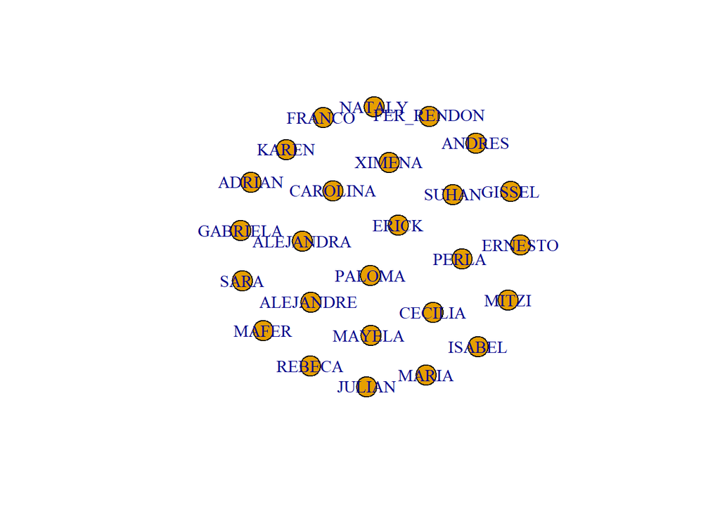

```r
pesad_1 <- graph_from_adjacency_matrix (pesad, mode = "undirected")
plot(pesad_1)
```

Primero:

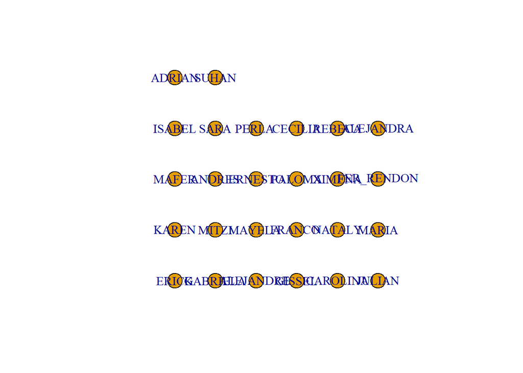

```r
pesad_lay_1 <-layout.grid (pesad_1)
plot(pesad_1, layout = pesad_lay_1)
```

Segundo:

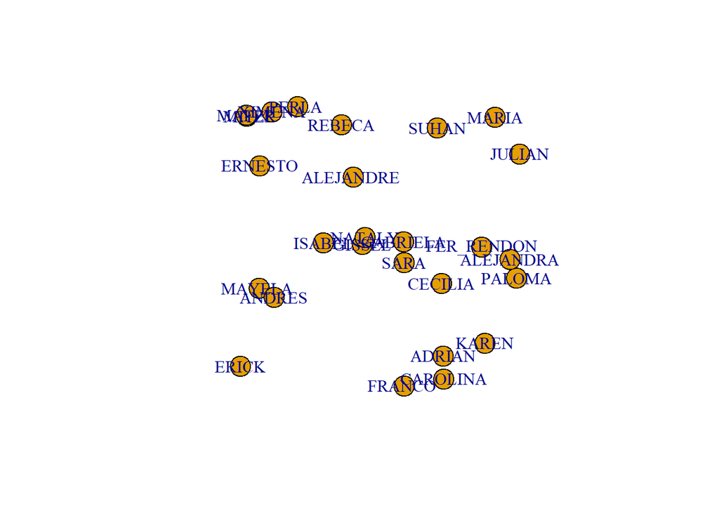

```r
pesad_lay_2 <-layout.lgl (pesad_1)
plot(pesad_1, layout = pesad_lay_2)
```

Tercero:

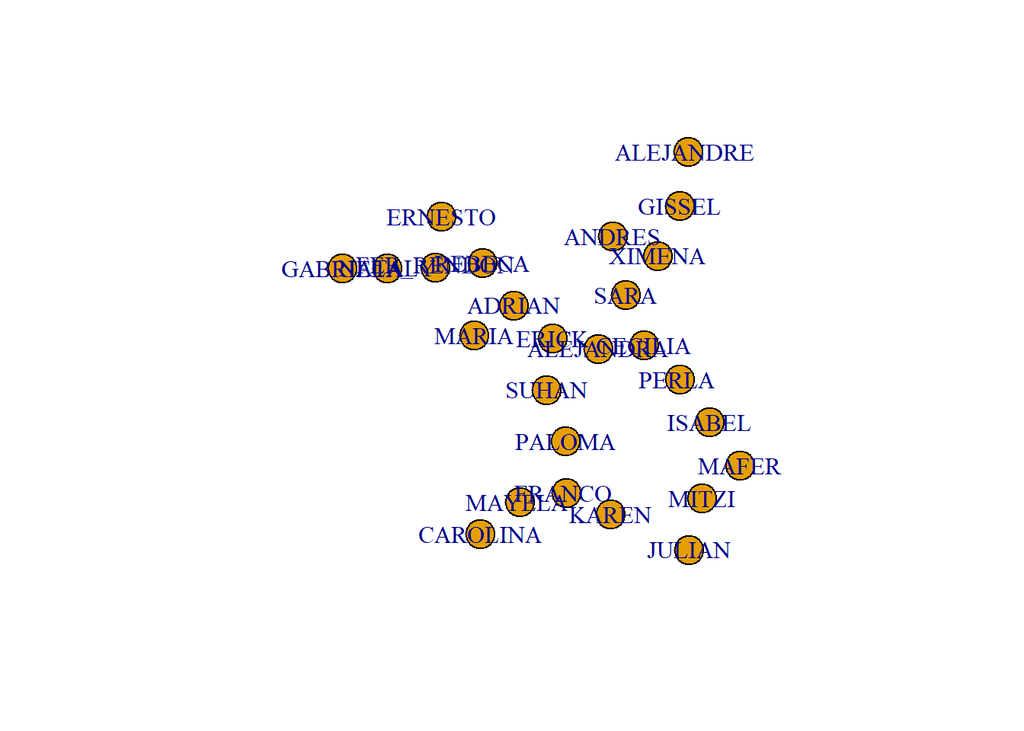

```r
pesad_lay_3 <-layout.mds (pesad_1)
plot(pesad_1, layout = pesad_lay_3)
```

## Dicotómica

Primero generamos un layout desde la matriz:

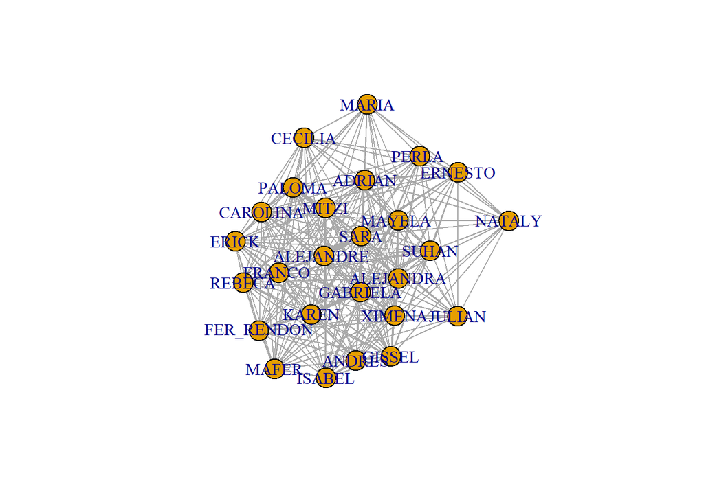

```r
dicot_1 <- graph_from_adjacency_matrix (dicot,mode = "undirected")
plot (dicot_1)
```

Primero:

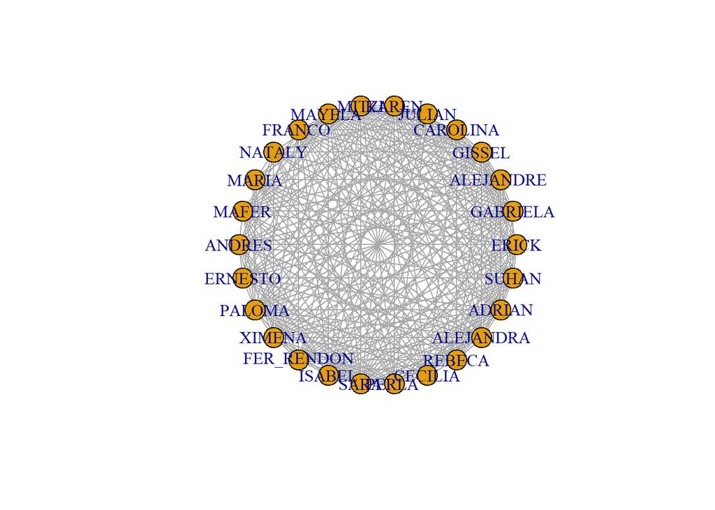

```r
dicot_lay_1 <-layout.circle (dicot_1)
plot(dicot_1, layout = dicot_lay_1)
```

Segundo:

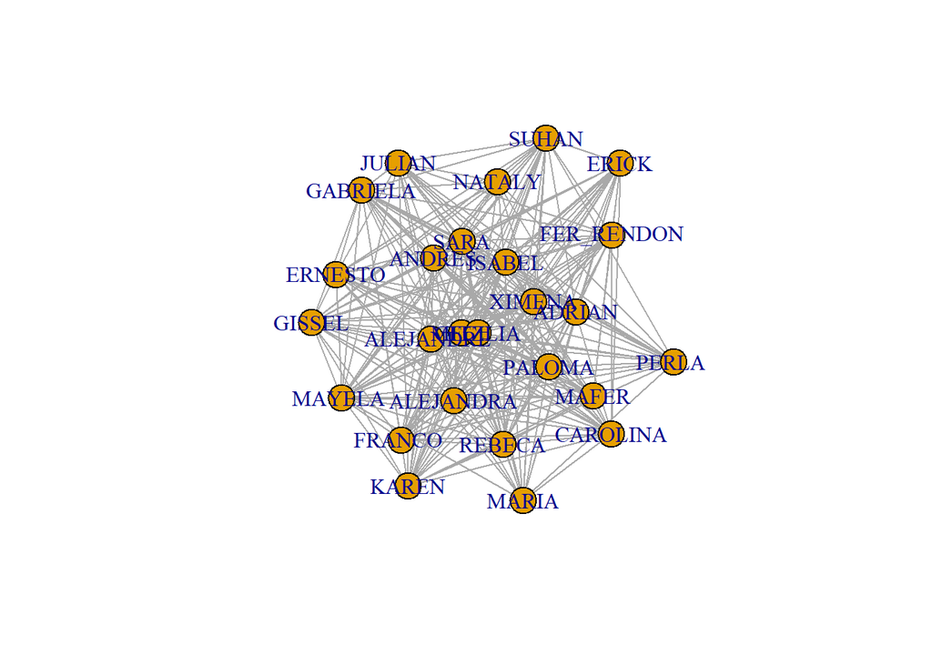

```r
dicot_lay_2 <-layout.drl (dicot_1)
plot(dicot_1, layout = dicot_lay_2)
```

Tercero:

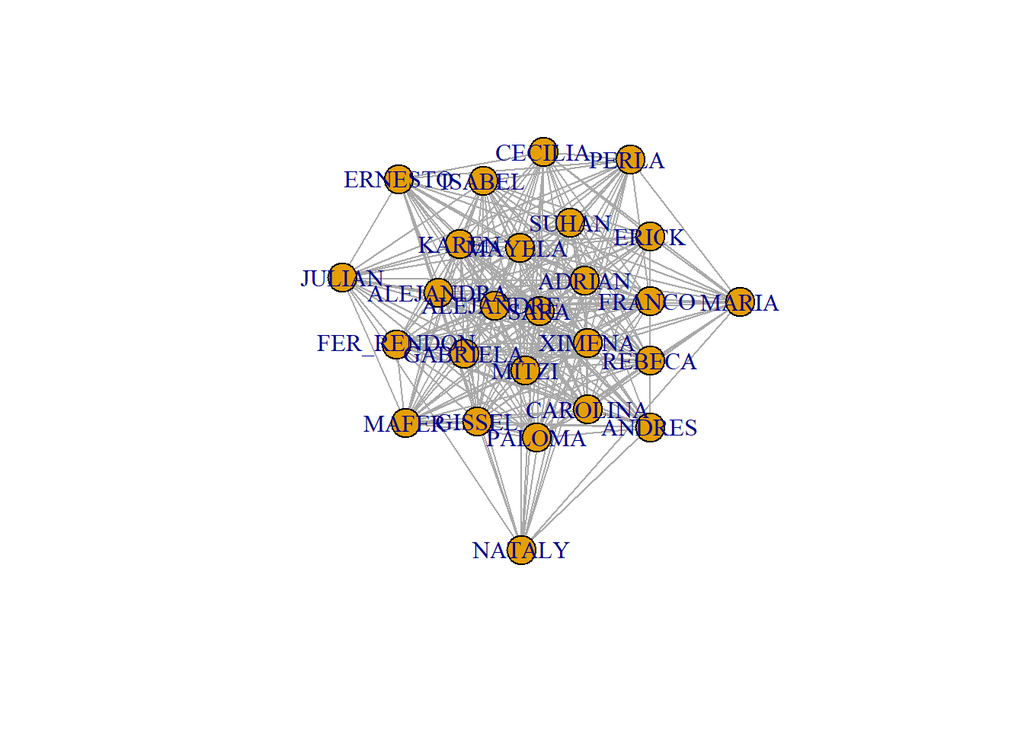

```r
dicot_lay_3 <-layout.gem (dicot_1)
plot(dicot_1, layout = dicot_lay_3)
```

*B) Distribucíon de conectividades (D)*

```r
conet_dicot <- degree (dicot_1)
conet_dicot
```

```
##      ERICK   GABRIELA ALEJANDRE      GISSEL   CAROLINA     JULIAN      KAREN
##         20         22         24         21         21         17         22
##      MITZI    MAYELA     FRANCO      NATALY      MARIA      MAFER     ANDRES
##         23         23         21         13         16         19         19
##    ERNESTO     PALOMA     XIMENA FER_RENDON     ISABEL       SARA     PERLA
##         17         21         23         20         20         25         18
##    CECILIA     REBECA  ALEJANDRA     ADRIAN      SUHAN
##         19         21         22         23         22
```

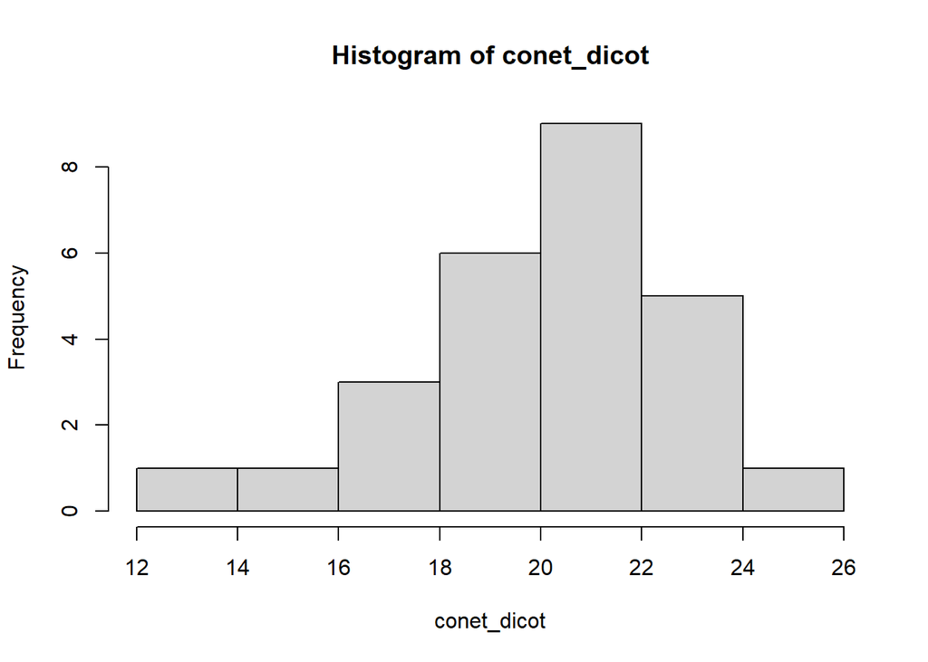

```r
hist (conet_dicot)
```

En el caso del histograma se observa en horizontal (donde dice conet_dicot) el numero de conexiones que va desde 12 a 26. En donde se puede observar por el tamaño de la barra en donde hay mayoría de conexiones (entre más grande sea) y la minoría (entre menor sea el tamaño). El histograma es unicamente para poder observar graficamente los resultados anteriores. También se puede ser logaritmicamente con: degree_distribution y log =“xy”.

*C) Nodos más conectados (D)*

```r
nod_dicot <- degree (dicot_1, mode = "all")
sort (nod_dicot, decreasing = T)
```

```
##       SARA ALEJANDRE       MITZI    MAYELA      XIMENA     ADRIAN   GABRIELA
##         25         24         23         23         23         23         22
##      KAREN  ALEJANDRA      SUHAN     GISSEL   CAROLINA    FRANCO      PALOMA
##         22         22         22         21         21         21         21
##     REBECA      ERICK FER_RENDON     ISABEL      MAFER     ANDRES    CECILIA
##         21         20         20         20         19         19         19
##     PERLA      JULIAN    ERNESTO      MARIA     NATALY
##         18         17         17         16         13
```

Con degree observamos las conexiones mientras que sort los ordena desendentemente. Por lo tanto, los primeros nodos que aparecen en la lista son los más conectados.

*D) Nodos más importantes con al menos tres medidas de centralidad (D)* Primero:

```r
centralization.closeness (graph = dicot_1)
```

```
## $res
##  [1] 0.8333333 0.8928571 0.9615385 0.8620690 0.8620690 0.7575758 0.8928571
##  [8] 0.9259259 0.9259259 0.8620690 0.6756757 0.7352941 0.8064516 0.8064516
## [15] 0.7575758 0.8620690 0.9259259 0.8333333 0.8333333 1.0000000 0.7812500
## [22] 0.8064516 0.8620690 0.8928571 0.9259259 0.8928571
##
## $centralization
## [1] 0.3124778
##
## $theoretical_max
## [1] 12.2449
```

Segundo:

```r
centralization.degree (graph = dicot_1)
```

```
## $res
##  [1] 20 22 24 21 21 17 22 23 23 21 13 16 19 19 17 21 23 20 20 25 18 19 21 22 23
## [26] 22
##
## $centralization
## [1] 0.1815385
##
## $theoretical_max
## [1] 650
```

Tercero:

```r
centralization.betweenness (graph = dicot_1)
```

```
## $res
##  [1] 1.350671 3.064198 3.185622 2.360828 1.949695 1.658990 1.889539 2.776160
##  [9] 3.721304 1.397735 0.957572 1.338441 1.117638 2.110828 1.739329 2.636426
## [17] 3.401737 1.290204 1.353388 4.365828 1.818783 2.555471 1.527655 2.630674
## [25] 3.465821 3.335461
##
## $centralization
## [1] 0.007268205
##
## $theoretical_max
## [1] 7500
```

*E) Clusters obtenidos con al menos tres métodos de clusterización (P y D)*

## Pesada

Primero:

```r
pesad_clus_1 <- cluster_leading_eigen (pesad_1)
membership (pesad_clus_1)
```

```
##      ERICK   GABRIELA ALEJANDRE      GISSEL   CAROLINA     JULIAN      KAREN
##          1          2          3          4          5          6          7
##      MITZI    MAYELA     FRANCO      NATALY      MARIA      MAFER     ANDRES
##          8          9         10         11         12         13         14
##    ERNESTO     PALOMA     XIMENA FER_RENDON     ISABEL       SARA     PERLA
##         15         16         17         18         19         20         21
##    CECILIA     REBECA  ALEJANDRA     ADRIAN      SUHAN
##         22         23         24         25         26
```

Segundo:

```r
pesad_clus_2 <- cluster_edge_betweenness (pesad_1)
membership (pesad_clus_2)
```

```
##      ERICK   GABRIELA ALEJANDRE      GISSEL   CAROLINA     JULIAN      KAREN
##          1          2          3          4          5          6          7
##      MITZI    MAYELA     FRANCO      NATALY      MARIA      MAFER     ANDRES
##          8          9         10         11         12         13         14
##    ERNESTO     PALOMA     XIMENA FER_RENDON     ISABEL       SARA     PERLA
##         15         16         17         18         19         20         21
##    CECILIA     REBECA  ALEJANDRA     ADRIAN      SUHAN
##         22         23         24         25         26
```

Tercero:

```r
pesad_clus_3 <- cluster_label_prop (pesad_1)
membership (pesad_clus_3)
```

```
##      ERICK   GABRIELA ALEJANDRE      GISSEL   CAROLINA     JULIAN      KAREN
##          1          2          3          4          5          6          7
##      MITZI    MAYELA     FRANCO      NATALY      MARIA      MAFER     ANDRES
##          8          9         10         11         12         13         14
##    ERNESTO     PALOMA     XIMENA FER_RENDON     ISABEL       SARA     PERLA
##         15         16         17         18         19         20         21
##    CECILIA     REBECA  ALEJANDRA     ADRIAN      SUHAN
##         22         23         24         25         26
```

## Dicotómica

Primero:

```r
dicot_clus_1 <- cluster_leiden (dicot_1)
membership (dicot_clus_1)
```

```
##      ERICK   GABRIELA ALEJANDRE      GISSEL   CAROLINA     JULIAN      KAREN
##          1          2          3          4          5          6          7
##      MITZI    MAYELA     FRANCO      NATALY      MARIA      MAFER     ANDRES
##          8          9         10         11         12         13         14
##    ERNESTO     PALOMA     XIMENA FER_RENDON     ISABEL       SARA     PERLA
##         15         16         17         18         19         20         21
##    CECILIA     REBECA  ALEJANDRA     ADRIAN      SUHAN
##         22         23         24         25         26
```

Segundo:

```r
dicot_clus_2 <- cluster_louvain (dicot_1)
membership (dicot_clus_2)
```

```
##      ERICK   GABRIELA ALEJANDRE      GISSEL   CAROLINA     JULIAN      KAREN
##          1          2          1          2          1          3          3
##      MITZI    MAYELA     FRANCO      NATALY      MARIA      MAFER     ANDRES
##          1          2          1          2          1          3          2
##    ERNESTO     PALOMA     XIMENA FER_RENDON     ISABEL       SARA     PERLA
##          2          1          3          3          3          2          2
##    CECILIA     REBECA  ALEJANDRA     ADRIAN      SUHAN
##          1          1          3          1          2
```

Tercero:

```r
dicot_clus_3 <- cluster_louvain (dicot_1)
membership (dicot_clus_3)
```

```
##      ERICK   GABRIELA ALEJANDRE      GISSEL   CAROLINA     JULIAN      KAREN
##          1          2          1          2          1          3          3
##      MITZI    MAYELA     FRANCO      NATALY      MARIA      MAFER     ANDRES
##          1          2          1          2          1          3          2
##    ERNESTO     PALOMA     XIMENA FER_RENDON     ISABEL       SARA     PERLA
##          2          1          3          3          3          2          2
##    CECILIA     REBECA  ALEJANDRA     ADRIAN      SUHAN
##          1          1          3          1          2
```

*F) Discute si las redes (P y D) son dirigidas o no.* Las redes no son dirigidas, porque no importan si ambos se relacionan. El proposito de las redes es observar los gustos, no necesariamente debe haber una afinidad de gustos entre ambas partes.